# Marseille

Simon Halliday

2015-November -11

```r
library(tidyr)
library(dplyr)
library(readr)
library(ggplot2)
```

Notice that you may have to install the `readr` package above.

Import the data as follows. Notice that this is *different* to how we’ve historically imported data. This is because the data are in a .txt file and so we can’t use `read.csv()`. Instead, we use `read_table()` from the `readr` package.

```r
Marseille <- read_table("/Users/shalliday/Google Drive/simondhalliday.github.io/bfh-textbook/indmarketdemand/MARS.txt", col_names = FALSE)
```

Look at the .txt file. Why do you think we had to specify the option `col_names = FALSE`?

Head the data to look at it (it has an issue in one column I haven’t been able to resolve yet, but it’s fine for our needs - can you find the issue?):

```r
head(Marseille)
```

```
## Source: local data frame [6 x 8]
##
##      X1    X2                 X3     X4    X5    X6    X7    X8
##   (int) (int)              (chr)  (int) (int) (int) (int) (int)
## 1     2 18064 ESCALE BASTIA 1002 880105  5415    77   110  4000
## 2     2 18070 ESCALE BASTIA 1002 880105  5415    44   120  2200
## 3     2 18078 PSS DE L'OPERA1002 880104  5505   214    90  6500
## 4     2 18081 GENTY PERTUIS 1002 880105 10080   214   150  6500
## 5     2 18085 MONTLAUR      1002 880102 10090    77   205  3600
## 6     2 18088 MONTLAUR      1002 880102 10090    44    60  1800
```

We need to rename the variables to ones that are consistent with what we need to understand:

```r
Marseille <-
  Marseille %>%
  rename(sellerb = X1, lot = X2, nbuyer = X3, date = X4, buyerc = X5, fish = X6, tempa = X7, tempb = X8)
Mars <-
  Marseille %>%
  mutate(weight = tempa/10, price = tempb/100)
head(Mars)
```

```
## Source: local data frame [6 x 10]
##
##   sellerb   lot             nbuyer   date buyerc  fish tempa tempb weight
##     (int) (int)              (chr)  (int)  (int) (int) (int) (int)  (dbl)
## 1       2 18064 ESCALE BASTIA 1002 880105   5415    77   110  4000   11.0
## 2       2 18070 ESCALE BASTIA 1002 880105   5415    44   120  2200   12.0
## 3       2 18078 PSS DE L'OPERA1002 880104   5505   214    90  6500    9.0
## 4       2 18081 GENTY PERTUIS 1002 880105  10080   214   150  6500   15.0
## 5       2 18085 MONTLAUR      1002 880102  10090    77   205  3600   20.5
## 6       2 18088 MONTLAUR      1002 880102  10090    44    60  1800    6.0
## Variables not shown: price (dbl)
```

Don’t run the code below yourselves (the sample size is huge and I don’t know how powerful your laptops are), just look at the plot. What does it suggest?

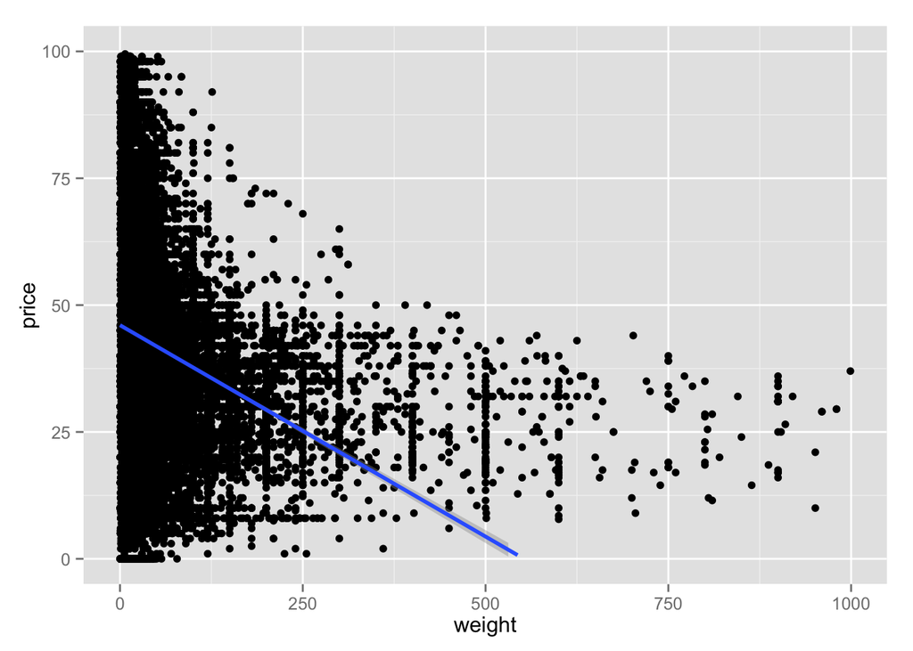

```r
Mars %>%
  ggplot(aes(x = weight, y = price)) +
  geom_point() +
  stat_smooth(method = "lm", formula = y ~ x, size = 1) +
  ylim(0, 100)
```

- What does the line correspond to?
- What kind of pattern are you able to see?

## A basic linear regression

Notice that you can run a linear regression with the whole sample of fish:

```r
m1 <- lm(price ~ weight, data = Mars)
summary(m1)
```

```
##
## Call:
## lm(formula = price ~ weight, data = Mars)
##
## Residuals:
##     Min      1Q  Median      3Q     Max
## -46.021 -15.462  -4.796  14.371  74.200
##
## Coefficients:
##              Estimate Std. Error t value Pr(>|t|)
## (Intercept) 46.045757   0.046576  988.61   <2e-16 ***
## weight      -0.083329   0.001331  -62.59   <2e-16 ***
## ---
## Signif. codes:  0 '***' 0.001 '**' 0.01 '*' 0.05 '.' 0.1 ' ' 1
##
## Residual standard error: 21.11 on 237159 degrees of freedom
## Multiple R-squared:  0.01625,    Adjusted R-squared:  0.01624
## F-statistic:  3917 on 1 and 237159 DF,  p-value: < 2.2e-16
```

- What is the sign on the for weight?
- What is weight’s significance?
- What does the relationship mean in terms of economic theory?

## Filtering the Fish

Consult the Marseille Data Description document to check what the different kinds of fish are.

I have generated the following graph for one of the kinds of fish (Merlan) by filtering and then graphing the data.

Filtering for Merlan:

```r
MarsFish44 <-
  Mars %>%
  filter(fish == 44)
```

Graphing the Merlan data:

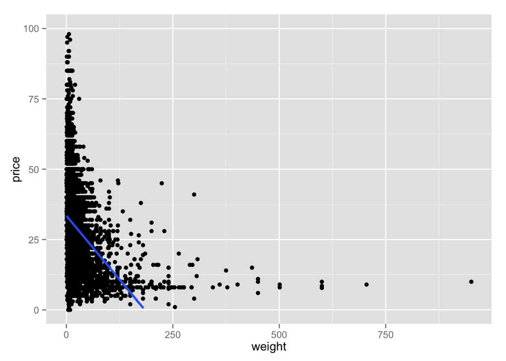

```r
MarsFish44 %>%
  ggplot(aes(x = weight, y = price)) +
  geom_point() +
  stat_smooth(method = "lm", formula = y ~ x, size = 1) +
  ylim(0, 100)
```

We can also run a linear regression just with the filtered Merlan data.

```r
OLSMerlan <- lm(price ~ weight, data = MarsFish44)
summary(OLSMerlan)
```

```
##
## Call:
## lm(formula = price ~ weight, data = MarsFish44)
##
## Residuals:
##     Min      1Q  Median      3Q     Max
## -32.662  -8.007   0.465   7.465 149.244
##
## Coefficients:
##              Estimate Std. Error t value Pr(>|t|)
## (Intercept) 33.442807   0.059853  558.75   <2e-16 ***
## weight      -0.181585   0.003063  -59.28   <2e-16 ***
## ---
## Signif. codes:  0 '***' 0.001 '**' 0.01 '*' 0.05 '.' 0.1 ' ' 1
##
## Residual standard error: 11.95 on 53679 degrees of freedom
## Multiple R-squared:  0.06145,    Adjusted R-squared:  0.06143
## F-statistic:  3515 on 1 and 53679 DF,  p-value: < 2.2e-16
```

Do the following:

- Choose a fish in which you are interested and construct a data frame that contains only that kind of fish.
- Construct a plot for that fish’s quantity-price observations
- Run a linear regression model of that fish’s price-quantity relationship
- Summarize the regression output.
- Submit your html of this later.

# Multiple regression with dummy variables

We want to include dummy variables for the different kinds of fish in our regressions. So we need to check whether the fish variable is numeric or a factor. We could `head()` the data and see, but we can also get a “TRUE” or “FALSE” report using the `is.numeric()` or `is.factor()` functions.

```r
is.numeric(Mars$fish)
```

```
## [1] TRUE
```

```r
is.factor(Mars$fish)
```

```
## [1] FALSE
```

As you can see, we need to change `fish` into a *factor* variable.

- How would you do this?
- Do the variables have the labels you’d like them to have? (i.e. the names of the fish)
- Is there a way to remedy this?

### Some ideas for factors

We need to take the information from the Marseille Data Details document and create two sets of columns using the following idea: `ObjectName <- c(content1, content2, ..., contentn)`.

I would recommend you call the one object (with the numbers) `FishLevels` because it corresponds to the *levels* of your factor variable.

I would recommend you call the second object `FishLabels` because it corresponds to the *labels* of the fish that you want.

You will then use the function `factor()` inside the function `mutate()` (which you already know).

You would then do something like the following (note this won’t work because I don’t have actual values:)

```r
MarsFactorFish <-
  Mars %>%
  mutate(fishvariablename = factor(fishvariablename, levels = FishLevels, labels = FishLabels))
```

You should get something like the following when you head your data:

```
## Source: local data frame [6 x 10]
##
##   sellerb   lot             nbuyer   date buyerc      fish tempa tempb
##     (int) (int)              (chr)  (int)  (int)    (fctr) (int) (int)
## 1       2 18064 ESCALE BASTIA 1002 880105   5415 Cabillaud   110  4000
## 2       2 18070 ESCALE BASTIA 1002 880105   5415    Merlan   120  2200
## 3       2 18078 PSS DE L'OPERA1002 880104   5505      Sole    90  6500
## 4       2 18081 GENTY PERTUIS 1002 880105  10080      Sole   150  6500
## 5       2 18085 MONTLAUR      1002 880102  10090 Cabillaud   205  3600
## 6       2 18088 MONTLAUR      1002 880102  10090    Merlan    60  1800
## Variables not shown: weight (dbl), price (dbl)
```

## Fish Factors in the Multiple Regression

Now, include the fish variables as factors in our regression

```r
m2 <- lm(price ~ weight + fish, data = Mars)
summary(m2)
```

[output not shown]

## xtable for pretty tables

I’m going to recommend you consider installing the package `xtable` for thinking about the production of decent-looking tables. This isn’t crucial for your project, but often useful.

```r
library(xtable)
xt1 <- xtable(m2)
print(xt1, type = "html", file = "fishy1.html")
```

|  | Estimate | Std. Error | t value | Pr(>\|t\|) |
| --- | --- | --- | --- | --- |
| (Intercept) | 32.2938 | 0.0676 | 477.93 | 0.0000 |
| weight | -0.0657 | 0.0010 | -65.24 | 0.0000 |
| fishCarrelet | -15.2820 | 0.3974 | -38.45 | 0.0000 |
| fishCabillaud | -0.8326 | 0.1060 | -7.85 | 0.0000 |
| fishLoup/Bar | 10.5332 | 0.1204 | 87.48 | 0.0000 |
| fish Raie Ange | 4.9014 | 0.1221 | 40.16 | 0.0000 |
| fishRaie (Entiere) | -1.6751 | 3.1613 | -0.53 | 0.5962 |
| fishSole | 31.1003 | 0.0859 | 362.22 | 0.0000 |
| fishTurbot | 36.6375 | 0.2362 | 155.08 | 0.0000 |
| fishCabillaud (Tranches) | 8.8999 | 0.6011 | 14.81 | 0.0000 |
| fishSole (Filet) | 39.1376 | 0.6514 | 60.08 | 0.0000 |
| fishAnnarrhyque (Filets) | 12.3755 | 0.2856 | 43.33 | 0.0000 |
| fishLoup (Filets) | 13.3184 | 0.1987 | 67.02 | 0.0000 |

End for today.